# Harvardx Machine Learning

# Comprehension Check: Smoothing

`r`r library(tidyverse) library(purrr) library(pdftools) library(lubridate)

`r`r span <- 60 / as.numeric(diff(range(dat$date))) fit <- dat %>% mutate(x = as.numeric(date)) %>% loess(deaths ~ x, data = ., span = span, degree = 1) dat %>% mutate(smooth = predict(fit, as.numeric(date))) %>% ggplot() + geom_point(aes(date, deaths)) + geom_line(aes(date, smooth), lwd = 2, col = 2)

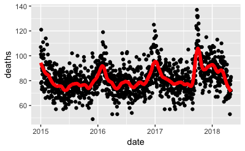

# Q2

Work with the same data as in Q1 to plot smooth estimates against day of the year, all on the same plot, but with different colors for each year. Which code produces the desired plot?

`r`r dat %>% mutate(smooth = predict(fit, as.numeric(date)), day = yday(date), year = as.character(year(date))) %>% ggplot(aes(day, smooth, col = year)) + geom_line(lwd = 2)

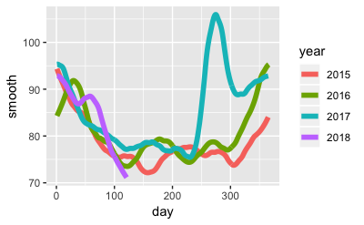

# Q3

Suppose we want to predict 2s and 7s in the mnist_27 dataset with just the second covariate. Can we do this? On first inspection it appears the data does not have much predictive power.

In fact, if we fit a regular logistic regression the coefficient for x_2 is not significant!

This can be seen using this code:

`r`r library(broom) mnist_27$train %>% glm(y ~ x_2, family = , data = .) %>% tidy()

| term | estimate | std.error | statistic | p.value |
| --- | --- | --- | --- | --- |
| (Intercept) | -0.09071891 | 0.2466017 | -0.3678763 | 0.7129655 |
| x_2 | 0.68547962 | 0.8273071 | 0.8285674 | 0.4073493 |

Plotting a scatterplot here is not useful since y is binary:

`r`r qplot(x_2, y, data = mnist_27$train)

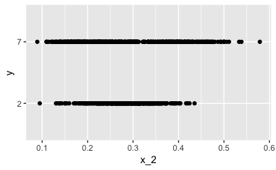

Explanation Note that there is indeed predictive power, but that the conditional probability is non-linear. The loess line can be plotted using the following code:

`r`r mnist_27$train %>% mutate(y = ifelse(y==, 1, 0)) %>% ggplot(aes(x_2, y)) + geom_smooth(method = )

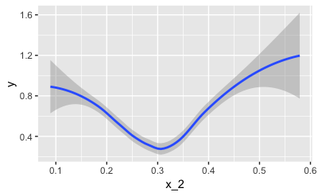

# Comprehension Check: Cross-validation

# Q1

Generate a set of random predictors and outcomes using the following code:

`r`r

```r
library(dplyr)
set.seed(1996)
n <- 1000
p <- 10000
x <- matrix(rnorm(n*p), n, p)
colnames(x) <- paste(\x\, 1:ncol(x), sep = \_\)
y <- rbinom(n, 1, 0.5) %>% factor()
x_subset <- x[ ,sample(p, 100)]
```

Because x and y are completely independent, you should not be able to predict y using x with accuracy greater than 0.5. Confirm this by running cross-validation using logistic regression to fit the model. Because we have so many predictors, we selected a random sample x_subset. Use the subset when training the model.

Which code correctly performs this cross-validation?

`r`r

```r
library(caret)
```

`r`r

```r
fit <- train(x_subset, y, method = \glm\)
fit$results
```

|  | parameter | Accuracy | Kappa | AccuracySD | KappaSD |
| --- | --- | --- | --- | --- | --- |
| 1 | none | 0.5078406 | 0.01318925 | 0.02336971 | 0.04626366 |

# Q2

Load the following codes to answer question 2. This came from someone in discussion forum

`r`r

```r
install.packages(\BiocManager\)
```

`r`r

```r
BiocManager::install(\genefilter\,version = \3.8\)
```

```
Error in loadNamespace(name) : there is no package called ‘BiocManager’
```

Which of the following lines of code correctly creates a vector of the p-values called pvals?

Answers : pvals <- tt$p.value

# Q3

Create an index ind with the column numbers of the predictors that were “statistically significantly” associated with y. Use a p-value cutoff of 0.01 to define “statistically significantly.”

How many predictors survive this cutoff?

`r`r `r`r ind <- which(pvals<=0.01) length(ind)

```
[1] 108
```

# Q4

Now re-run the cross-validation after redefinining x_subset to be the subset of x defined by the columns showing “statistically significant” association with y.

What is the accuracy now?

`r`r `r`r #x_subset <- x[ ,sample(p, 100)] x_subset <- x[,ind] fit <- train(x_subset, y, method = ) fit

```
Generalized Linear Model

1000 samples
 108 predictor
   2 classes: '0', '1'

No pre-processing
Resampling: Bootstrapped (25 reps)
Summary of sample sizes: 1000, 1000, 1000, 1000, 1000, 1000, ...
Resampling results:

  Accuracy   Kappa
  0.7609065  0.5210389
```

# Q5

Re-run the cross-validation again, but this time using kNN. Try out the following grid k = seq(101, 301, 25) of tuning parameters. Make a plot of the resulting accuracies.

Which code is correct?

`r`r `r`r library(dslabs) data(tissue_gene_expression) str(tissue_gene_expression)

```
List of 2
 $ x: num [1:189, 1:500] 9.83 9.63 9.69 9.99 9.58 ...
  ..- attr(*, \dimnames\)=List of 2
  .. ..$ : chr [1:189] \cerebellum_1\ \cerebellum_2\ \cerebellum_3\ \cerebellum_4\ ...
  .. ..$ : chr [1:500] \MAML1\ \LHPP\ \SEPT10\ \B3GNT4\ ...
 $ y: Factor w/ 7 levels \cerebellum\,\colon\,..: 1 1 1 1 1 1 1 1 1 1 ...
```

`r`r `r`r fit <- train(y~x, method = ,data=tissue_gene_expression)

```
Error in data[, all.vars(Terms), drop = FALSE] :
  incorrect number of dimensions
```

# Comprehension Check: Bootstrap

# Q1

The createResample function can be used to create bootstrap samples. For example, we can create 10 bootstrap samples for the mnist_27 dataset like this:

`r`r `r`r library(dslabs) library(caret) data(mnist_27) set.seed(1995) indexes <- createResample(mnist_27$train$y, 10)

Enter the numbers of 3,4 and 7 appear in indexes

`r`r `r`r sum(indexes[[1]] == 3)

```
[1] 1
```

`r`r `r`r sum(indexes[[1]] == 4)

```
[1] 4
```

`r`r `r`r sum(indexes[[1]] == 7)

```
[1] 0
```

# Q2

We see that some numbers appear more than once and others appear no times. This has to be this way for each dataset to be independent. Repeat the exercise for all the resampled indexes.

What is the total number of times that 3 appears in all of the resampled indexes?

`r`r `r`r x=sapply(indexes, function(ind){ sum(ind == 3) }) sum(x)

```
[1] 11
```

# Q3

Generate a random dataset using the following code:

`r`r `r`r set.seed(1) y <- rnorm(100, 0, 1)

Estimate the 75th quantile, which we know is qnorm(0.75), with the sample quantile: quantile(y, 0.75).

Run a Monte Carlo simulation with 10,000 repetitions to learn the expected value and standard error of this random variable. Set the seed to 1.

`r`r `r`r set.seed(1) B <- 10000 q_75 <- replicate(B, { y <- rnorm(100, 0, 1) quantile(y, 0.75) }) mean(q_75)

```
[1] 0.6656107
```

`r`r `r`r sd(q_75)

```
[1] 0.1353809
```

# Q4

In practice, we can’t run a Monte Carlo simulation. Use 10 bootstrap samples to estimate the standard error using just the initial sample y. Set the seed to 1.

`r`r `r`r set.seed(1) indexes <- createResample(y, 10) q_75_star <- sapply(indexes, function(ind){ y_star <- y[ind] quantile(y_star, 0.75) }) mean(q_75_star)

```
[1] 0.7312648
```

`r`r `r`r sd(q_75_star)

```
[1] 0.07419278
```

# Q5

Repeat the exercise from Q4 but with 10,000 bootstrap samples instead of 10. Set the seed to 1.

`r`r `r`r set.seed(1) indexes <- createResample(y, 10000) q_75_star <- sapply(indexes, function(ind){ y_star <- y[ind] quantile(y_star, 0.75) }) mean(q_75_star)

```
[1] 0.6737512
```

`r`r `r`r sd(q_75_star)

```
[1] 0.0930575
```

# Notes from Rafalab regarding generative model

Let’s start with a very simple and uninteresting, yet illustrative, case: the example related to predicting sex from height.

`r`r

```r
library(caret)
library(dslabs)
data(\heights\)
y <- heights$height
set.seed(2)
test_index <- createDataPartition(y, times = 1, p = 0.5, list = FALSE)
train_set <- heights %>% slice(-test_index)
test_set <- heights %>% slice(test_index)
```

Using the predictor under the assumption it is normal distribution

`r`r

```r
params <- train_set %>%
  group_by(sex) %>%
  summarize(avg = mean(height), sd = sd(height))
params
```

| sex | avg | sd |
| --- | --- | --- |
| Female | 64.53464 | 4.016066 |
| Male | 69.32105 | 3.517273 |

The prevalence, which we will denote with  
π=Pr(Y=1), can be estimated from the data with:

`r`r

```r
pi <- train_set %>%
  summarize(pi=mean(sex==\Female\)) %>%
  .$pi
pi
```

```
[1] 0.2290076
```

Now we can use our estimates of average and standard deviation to get an actual rule:

`r`r

```r
x <- test_set$height
f0 <- dnorm(x, params$avg[2], params$sd[2])
f1 <- dnorm(x, params$avg[1], params$sd[1])
p_hat_bayes <- f1*pi / (f1*pi + f0*(1 - pi))
```

# Controlling prevalence

As we discussed earlier, our sample has a much lower prevalence, 0.229, than the general population. So if we use the rule p(x)>0.5 to predict females, our accuracy will be affected due to the low sensitivity:

`r`r

```r
y_hat_bayes <- ifelse(p_hat_bayes > 0.5, \Female\, \Male\)
sensitivity(data = factor(y_hat_bayes), reference = factor(test_set$sex))
```

```
[1] 0.2627119
```

`r`r

```r
specificity(data = factor(y_hat_bayes), reference = factor(test_set$sex))
```

[output not shown]

This is due mainly to the fact that π is substantially less than 0.5, so we tend to predict Male more often. It makes sense for a machine learning algorithm to do this in our sample because we do have a higher percentage of males. But if we were to extrapolate this to a general population, our overall accuracy would be affected by the low sensitivity.

The Naive Bayes approach gives us a direct way to correct this since we can simply force  
pi to be, for example, π. So to balance specificity and sensitivity, instead of changing the cutoff in the decision rule, we could simply change π:

`r`r

```r
p_hat_bayes_unbiased <- f1*0.5 / (f1*0.5 + f0*(1-0.5))
y_hat_bayes_unbiased <- ifelse(p_hat_bayes_unbiased> 0.5, \Female\, \Male\)
```

The new rule also gives us a very intuitive cutoff between 66-67, which is about the middle of the female and male average heights:

`r`r

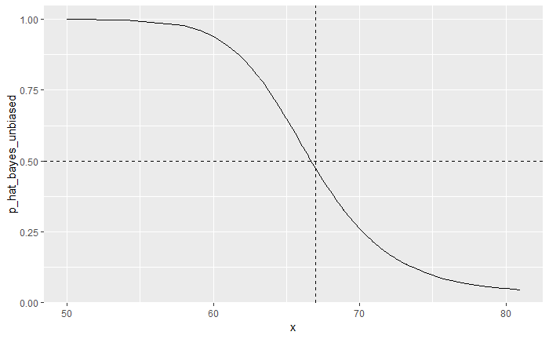

```r
qplot(x, p_hat_bayes_unbiased, geom = \line\) +
  geom_hline(yintercept = 0.5, lty = 2) +
  geom_vline(xintercept = 67, lty = 2)
```

# Comprehension Check: Generative Models

In the following exercises, we are going to apply LDA and QDA to the tissue_gene_expression dataset. We will start with simple examples based on this dataset and then develop a realistic example.

# Q1

1 point possible (graded) Create a dataset of samples from just cerebellum and hippocampus, two parts of the brain, and a predictor matrix with 10 randomly selected columns using the following code:

`r`r set.seed(1993) data(_gene_expression) ind <- which(tissue_gene_expression$y %in% c(\cerebellum\, \hippocampus\)) y <- droplevels(tissue_gene_expression$y[ind]) x <- tissue_gene_expression$x[ind, ] x <- x[, sample(ncol(x), 10)]

Use the train function to estimate the accuracy of LDA. What is the accuracy?

`r`r library(caret)

`r`r fit <- train(x, y, method = ) fit$results

|  | parameter | Accuracy | Kappa | AccuracySD | KappaSD |
| --- | --- | --- | --- | --- | --- |
| 1 | none | 0.8707879 | 0.7358585 | 0.06133693 | 0.1260368 |

# Q2

In this case, LDA fits two 10-dimensional normal distributions. Look at the fitted model by looking at the finalModel component of the result of train. Notice there is a component called means that includes the estimated means of both distributions. Plot the mean vectors against each other and determine which predictors (genes) appear to be driving the algorithm.

Which TWO genes appear to be driving the algorithm?

`r`r library(dplyr) fit$finalModel

```
Call:
lda(x, grouping = y)

Prior probabilities of groups:
 cerebellum hippocampus
  0.5507246   0.4492754

Group means:
              SAPCD1    HEMK1    PLCB1     SPI1    RAB1B     MSH4   IL18R1     OAZ2    FOXE3 C21orf62
cerebellum  6.986817 7.438612 5.040267 6.048843 10.26148 5.325845 5.421491 10.00821 6.022749 5.911605
hippocampus 7.027106 7.350232 5.023790 6.490261 10.24046 5.247354 5.539534  9.65903 6.062418 5.721539

Coefficients of linear discriminants:
                LD1
SAPCD1   -1.0380541
HEMK1    -1.3300757
PLCB1     0.2590667
SPI1      3.1261507
RAB1B     0.1836489
MSH4     -2.8846563
IL18R1    3.6575231
OAZ2     -1.1365484
FOXE3    -0.8198930
C21orf62 -3.4085635
```

`r`r t(fit$finalModel$means) %>% data.frame() %>% mutate(predictor_name = rownames(.)) %>% ggplot(aes(cerebellum, hippocampus, label = predictor_name)) + geom_point() + geom_text() + geom_abline()

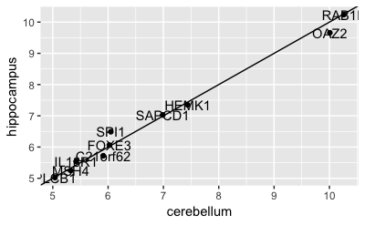

# Q3

Repeat the exercise in Q1 with QDA.

Create a dataset of samples from just cerebellum and hippocampus, two parts of the brain, and a predictor matrix with 10 randomly selected columns using the following code:

`r`r set.seed(1993) data(_gene_expression) ind <- which(tissue_gene_expression$y %in% c(\cerebellum\, \hippocampus\)) y <- droplevels(tissue_gene_expression$y[ind]) x <- tissue_gene_expression$x[ind, ] x <- x[, sample(ncol(x), 10)]

Use the train function to estimate the accuracy of QDA.

What is the accuracy?

`r`r library(caret) fit_qda <- train(x, y, method = ) fit$results

[output not shown]

# Q4

Which TWO genes drive the algorithm when using QDA instead of LDA?

`r`r t(fit_qda$finalModel$means) %>% data.frame() %>% mutate(predictor_name = rownames(.)) %>% ggplot(aes(cerebellum, hippocampus, label = predictor_name)) + geom_point() + geom_text() + geom_abline()

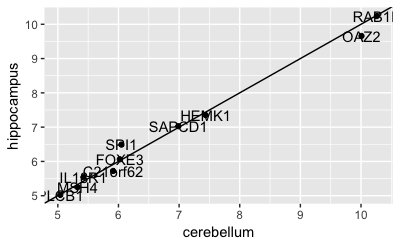

# Q5

Which TWO genes drive the algorithm after performing the scaling?

|  | Accuracy |
| --- | --- |
| 1 | 0.8595389 |

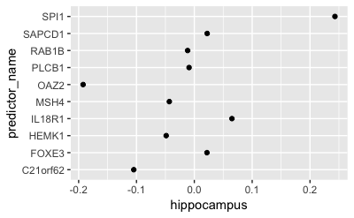

You can see that it is different genes driving the algorithm now. This is because the predictor means change. In the previous exercises we saw that both LDA and QDA approaches worked well. For further exploration of the data, you can plot the predictor values for the two genes with the largest differences between the two groups in a scatter plot to see how they appear to follow a bivariate distribution as assumed by the LDA and QDA approaches, coloring the points by the outcome, using the following code:

`r`r d <- apply(fit_lda$finalModel$means, 2, diff) ind <- order(abs(d), decreasing = TRUE)[1:2] plot(x[, ind], col = y)

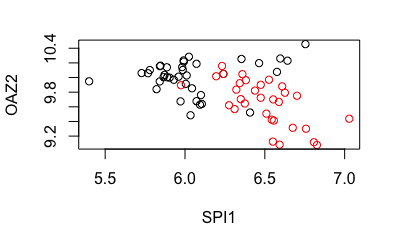

`r`r set.seed(1993) data(_gene_expression) y <- tissue_gene_expression$y x <- tissue_gene_expression$x x <- x[, sample(ncol(x), 10)]

`r`r fit_lda <- train(x, y, method = , preProcess = ) fit_lda$results[]

|  | Accuracy |
| --- | --- |
| 1 | 0.8194837 |

# Comprehension Check: Trees and Random Forests

# Q1

Create a simple dataset where the outcome grows 0.75 units on average for every increase in a predictor, using this code:

`r`r library(rpart) n <- 1000 sigma <- 0.25 x <- rnorm(n, 0, 1) y <- 0.75 * x + rnorm(n, 0, sigma) dat <- data.frame(x = x, y = y)

Which code correctly uses rpart to fit a regression tree and saves the result to fit?

`r`r fit <- rpart(y ~ ., data = dat)

`r`r plot(fit, margin = 0.1) text(fit, cex = 0.75)

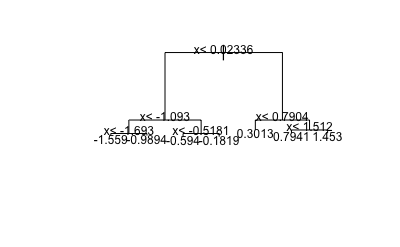

# Q3

Below is most of the code to make a scatter plot of y versus x along with the predicted values based on the fit.

`r`r dat %>% mutate(y_hat = predict(fit)) %>% ggplot() + geom_point(aes(x, y)) + geom_step(aes(x, y_hat), col=2)

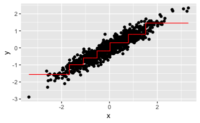

# Q4

Now run Random Forests instead of a regression tree using randomForest from the **randomForest** package, and remake the scatterplot with the prediction line. Part of the code is provided for you below.

`r`r library(randomForest) fit <- randomForest(y ~ x, data = dat) dat %>% mutate(y_hat = predict(fit)) %>% ggplot() + geom_point(aes(x, y)) + geom_step(aes(x, y_hat), col = 2)

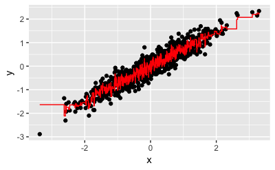

`r`r plot(fit)

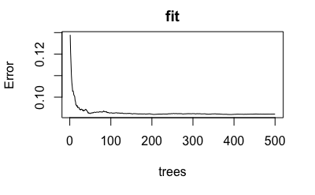

# Q6

It seems that the default values for the Random Forest result in an estimate that is too flexible (unsmooth). Re-run the Random Forest but this time with a node size of 50 and a maximum of 25 nodes. Remake the plot.

Part of the code is provided for you below.

`r`r library(randomForest) fit <- randomForest(y ~ x, data = dat, nodesize = 50, maxnodes = 25) dat %>% mutate(y_hat = predict(fit)) %>% ggplot() + geom_point(aes(x, y)) + geom_step(aes(x, y_hat), col = 2)

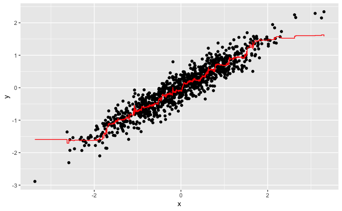

# Comprehension Check: Caret Package

# Q3

```r
library(caret)
library(rpart)
library(dslabs)
data(tissue_gene_expression)
fit <- rpart(y ~ x, data = tissue_gene_expression, control = rpart.control(cp = 0.02, minsplit = 2))
confusionMatrix(predict(fit,tissue_gene_expression,type="class"),tissue_gene_expression$y)$overall["Accuracy"]
```

```
Accuracy
0.994709
```

# Q3

Use the rpart function to fit a classification tree to the tissue_gene_expression dataset. Use the train function to estimate the accuracy. Try out cp values of seq(0, 0.1, 0.01). Plot the accuracies to report the results of the best model. Set the seed to 1991.

Which value of cp gives the highest accuracy?

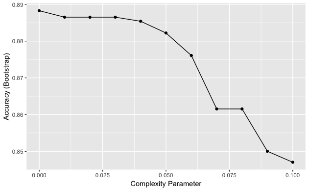

```r
library(caret)
library(dslabs)
set.seed(1991)
data("tissue_gene_expression")

fit <- with(tissue_gene_expression,
                train(x, y, method = "rpart",
                      tuneGrid = data.frame(cp = seq(0, 0.1, 0.01))))

ggplot(fit)
```

```r
confusionMatrix(fit)
```

```
Bootstrapped (25 reps) Confusion Matrix

(entries are percentual average cell counts across resamples)

             Reference
Prediction    cerebellum colon endometrium hippocampus kidney liver placenta
  cerebellum        19.3   0.0         0.3         1.1    0.3   0.0      0.2
  colon              0.3  16.5         0.1         0.0    0.1   0.0      0.1
  endometrium        0.1   0.2         5.6         0.1    1.5   0.1      1.3
  hippocampus        0.2   0.0         0.0        15.3    0.1   0.0      0.0
  kidney             0.3   0.3         1.7         0.1   18.7   0.5      0.3
  liver              0.0   0.0         0.3         0.0    0.3  12.6      0.2
  placenta           0.2   0.0         0.4         0.0    0.5   0.1      0.9

 Accuracy (average) : 0.8878
```

# Q5

Note that there are only 6 placentas in the dataset. By default, rpart requires 20 observations before splitting a node. That means that it is difficult to have a node in which placentas are the majority. Rerun the analysis you did in the exercise in Q3, but this time, allow rpart to split any node by using the argument control = rpart.control(minsplit = 0). Look at the confusion matrix again to determine whether the accuracy increases. Again, set the seed to 1991.

What is the accuracy now?

```r
library(caret)
library(dslabs)
set.seed(1991)
data("tissue_gene_expression")

fit <- with(tissue_gene_expression,
                train(x, y, method = "rpart",
                      control = rpart.control(minsplit = 0),
                      tuneGrid = data.frame(cp = seq(0, 0.1, 0.01))))

confusionMatrix(fit)
```

```
Bootstrapped (25 reps) Confusion Matrix

(entries are percentual average cell counts across resamples)

             Reference
Prediction    cerebellum colon endometrium hippocampus kidney liver placenta
  cerebellum        19.5   0.0         0.2         0.9    0.4   0.0      0.1
  colon              0.3  16.5         0.1         0.0    0.1   0.0      0.1
  endometrium        0.1   0.2         6.4         0.1    0.9   0.1      0.5
  hippocampus        0.2   0.0         0.0        15.6    0.1   0.0      0.0
  kidney             0.3   0.3         0.9         0.1   19.1   0.5      0.3
  liver              0.0   0.0         0.3         0.0    0.3  12.6      0.2
  placenta           0.1   0.1         0.5         0.0    0.6   0.1      1.8

 Accuracy (average) : 0.9141
```

# Q6

Plot the tree from the best fitting model of the analysis you ran in Q5. Which gene is at the first split?

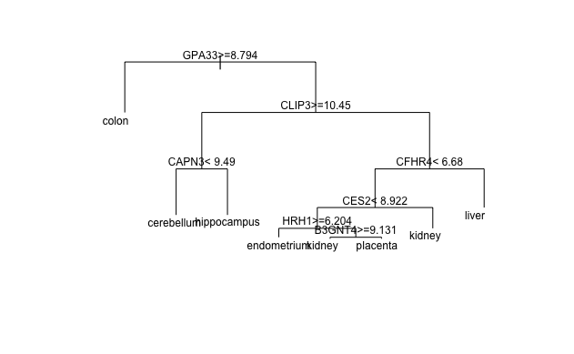

```r
plot(fit$finalModel, margin = 0.1)
text(fit$finalModel, cex = 0.75)
```

# Q7

We can see that with just seven genes, we are able to predict the tissue type. Now let’s see if we can predict the tissue type with even fewer genes using a Random Forest. Use the train function and the rf method to train a Random Forest. Try out values of mtry ranging from seq(50, 200, 25) (you can also explore other values on your own). What mtry value maximizes accuracy? To permit small nodesize to grow as we did with the classification trees, use the following argument: nodesize = 1.

Note: This exercise will take some time to run. If you want to test out your code first, try using smaller values with ntree. Set the seed to 1991 again.

What value of mtry maximizes accuracy?

```r
library(caret)
library(dslabs)
set.seed(1991)
data("tissue_gene_expression")

fit <- with(tissue_gene_expression,
                train(x, y, method = "rf",
                      nodesize = 1,
                      tuneGrid = data.frame(mtry = seq(50, 200, 25))))

confusionMatrix(fit)
```

```
Bootstrapped (25 reps) Confusion Matrix

(entries are percentual average cell counts across resamples)

             Reference
Prediction    cerebellum colon endometrium hippocampus kidney liver placenta
  cerebellum        20.3   0.0         0.0         0.0    0.0   0.0      0.0
  colon              0.0  17.1         0.0         0.0    0.1   0.0      0.1
  endometrium        0.0   0.0         8.2         0.0    0.0   0.0      0.0
  hippocampus        0.0   0.0         0.0        16.6    0.0   0.0      0.0
  kidney             0.2   0.0         0.0         0.0   21.4   0.0      0.0
  liver              0.0   0.0         0.0         0.0    0.0  13.2      0.0
  placenta           0.0   0.0         0.0         0.0    0.0   0.0      2.9

 Accuracy (average) : 0.9971
```

# Q8

Use the function varImp on the output of train and save it to an object called imp.

```r
imp <- varImp(fit)
```

```r
library(dplyr)
data_frame(term = rownames(imp$importance),
            importance = imp$importance$Overall) %>%
    mutate(rank = rank(-importance)) %>% arrange(desc(importance)) %>%
    filter(term %in% tree_terms)
```

[output not shown]